# Cardio Good Fitness Project

# Connie Xavier

### Part 1: Overview of Data

```python
#import relevant libraries
import numpy as np
import pandas as pd
import matplotlib.pyplot as plt
import seaborn as sns
import plotly.express as px
%matplotlib inline
```

```python
from google.colab import drive
drive.mount('/content/drive')
```

```python
#read the data and copy the data to another variable to avoid any changes to the original data
cardio = pd.read_csv('/content/drive/MyDrive/Data Science/PGP-MLAI/Python/CardioGoodFitness.csv')
df = cardio.copy()
```

```python
#check the first 5 rows of data to check data has been loaded properly
df.head()
```

|  | Product | Age | Gender | Education | MaritalStatus | Usage | Fitness | Income | Miles |
| --- | --- | --- | --- | --- | --- | --- | --- | --- | --- |
| 0 | TM195 | 18 | Male | 14 | Single | 3 | 4 | 29562 | 112 |
| 1 | TM195 | 19 | Male | 15 | Single | 2 | 3 | 31836 | 75 |
| 2 | TM195 | 19 | Female | 14 | Partnered | 4 | 3 | 30699 | 66 |
| 3 | TM195 | 19 | Male | 12 | Single | 3 | 3 | 32973 | 85 |
| 4 | TM195 | 20 | Male | 13 | Partnered | 4 | 2 | 35247 | 47 |

- The Product column contains the model no. of the treadmill.
- All data seems to be coming in correctly.

```python
#check the shape of the data
df.shape
```

```
(180, 9)
```

- There are 180 rows and 9 columns in the dataset.

```python
#check for missing values and datatype of the columns
df.info()
```

```
<class 'pandas.core.frame.DataFrame'>
RangeIndex: 180 entries, 0 to 179
Data columns (total 9 columns):
 #   Column         Non-Null Count  Dtype
---  ------         --------------  -----
 0   Product        180 non-null    object
 1   Age            180 non-null    int64
 2   Gender         180 non-null    object
 3   Education      180 non-null    int64
 4   MaritalStatus  180 non-null    object
 5   Usage          180 non-null    int64
 6   Fitness        180 non-null    int64
 7   Income         180 non-null    int64
 8   Miles          180 non-null    int64
dtypes: int64(6), object(3)
memory usage: 12.8+ KB
```

- There are no missing values in the dataset since all columns have 180 observations.
- There are 3 object datatype variables (product number, gender, and marital status), and 6 variables with int64 datatypes.

```python
#look at the summary statistics of the numerical variables of the dataset
df.describe().T
```

|  | count | mean | std | min | 25% | 50% | 75% | max |
| --- | --- | --- | --- | --- | --- | --- | --- | --- |
| Age | 180.0 | 28.788889 | 6.943498 | 18.0 | 24.00 | 26.0 | 33.00 | 50.0 |
| Education | 180.0 | 15.572222 | 1.617055 | 12.0 | 14.00 | 16.0 | 16.00 | 21.0 |
| Usage | 180.0 | 3.455556 | 1.084797 | 2.0 | 3.00 | 3.0 | 4.00 | 7.0 |
| Fitness | 180.0 | 3.311111 | 0.958869 | 1.0 | 3.00 | 3.0 | 4.00 | 5.0 |
| Income | 180.0 | 53719.577778 | 16506.684226 | 29562.0 | 44058.75 | 50596.5 | 58668.00 | 104581.0 |
| Miles | 180.0 | 103.194444 | 51.863605 | 21.0 | 66.00 | 94.0 | 114.75 | 360.0 |

- The age ranges from 18 to 50 years old, with most customers in their mid-20s. Age is right-skewed since there is a big gap between the 75% and max values.
- The mean and median are close in value for the Education, Usage, and Fitness variables.
- Education ranges from 12 to 21 years, which is assumed to mean all customers have finished high school and some went on to get graduate degrees.
- Most customers want to use the treadmill around 3 times a week, with the max being 7 times/week which makes sense.
- Most customers are of "average" fitness level, with the mean and median being close to 3 out of a 1-5 scale.
- The income variable is right skewed as there is a bigger gap between the 75% and max value than the 25% and min value. Due to the values, it is assumed the income is yearly.
- The Miles variable has a large standard deviation, meaning the distribution is very spread out. The number of miles ranges from 21 to 360. Number of miles assumed to represent miles per week (based on Project Discussion Forum)

```python
#While it is possible to have customers with the same characteristics, let's check for duplicated rows in the data
df.duplicated().sum()
```

```
0
```

- There are no duplicated rows in the dataset.

```python
#check that the variables that can only take on a set number of values are doing so.
cols=['Gender','MaritalStatus','Fitness','Usage']
for x in cols:
  print(df[x].value_counts())
```

```
Male      104
Female     76
Name: Gender, dtype: int64
Partnered    107
Single        73
Name: MaritalStatus, dtype: int64
3    97
5    31
2    26
4    24
1     2
Name: Fitness, dtype: int64
3    69
4    52
2    33
5    17
6     7
7     2
Name: Usage, dtype: int64
```

- The Gender (M/F), Marital Status (single/Partnered, Fitness level (1-5), and Usage (2-7) columns all take on the expected range of values.

### Part 2: Univariate Analysis

```python
# Defining the function for creating boxplot and histogram
def histogram_boxplot(data, feature, figsize=(12, 7), kde=False, bins=None):
    """
    Boxplot and histogram combined

    data: dataframe
    feature: dataframe column
    figsize: size of figure (default (12,7))
    kde: whether to show the density curve (default False)
    bins: number of bins for histogram (default None)
    """
    f2, (ax_box2, ax_hist2) = plt.subplots(
        nrows=2,  # Number of rows of the subplot grid= 2
        sharex=True,  # x-axis will be shared among all subplots
        gridspec_kw={"height_ratios": (0.25, 0.75)},
        figsize=figsize)  # creating the 2 subplots

    sns.boxplot(data=data, x=feature, ax=ax_box2, showmeans=True, color="mediumturquoise")  # boxplot will be created and a star will indicate the mean value of the column

    if bins:
      sns.histplot(data=data, x=feature, kde=kde, ax=ax_hist2, bins=bins, color="mediumpurple")
    else:
      sns.histplot(data=data, x=feature, kde=kde, ax=ax_hist2, color="mediumpurple")  # For histogram

    ax_hist2.axvline(data[feature].mean(), color="green", linestyle="--")  # Add mean to the histogram

    ax_hist2.axvline(data[feature].median(), color="black", linestyle="-")  # Add median to the histogram
```

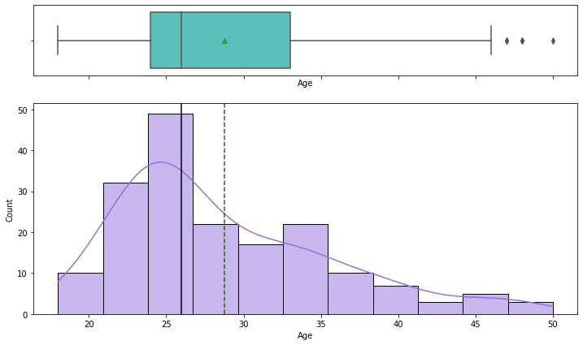

```python
#Explore the 'Age' variable
histogram_boxplot(data = df, feature = 'Age', kde=True)
```

It is clear from the above plot that the data distribution is right skewed, with the mean being to the right of the median. There are a few outliers to the right. Most customers are around 25 years old.

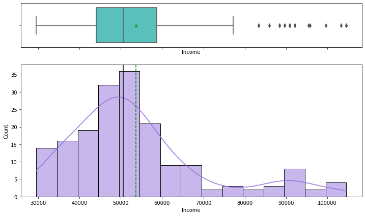

```python
#Explore the 'Income' variable
histogram_boxplot(data = df, feature = 'Income', kde=True)
```

The distribution is right skewed with a lot of outliers towards the right. The mean and median are under $55,000.

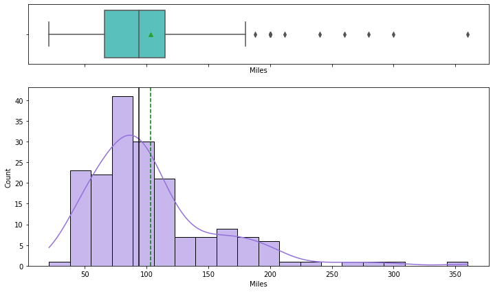

```python
#Explore the 'Miles' variable
histogram_boxplot(data = df, feature = 'Miles', kde=True)
```

The distribution is right skewed as most runners expect to run around 75 miles, with the mean and median around 100 miles. There are very few people who expect to run over 200 miles, as the bins above 200 are very small. There could be true outliers here depending on the timeframe defined. We expect that as the fitness level increases, the more miles someone expects to run.

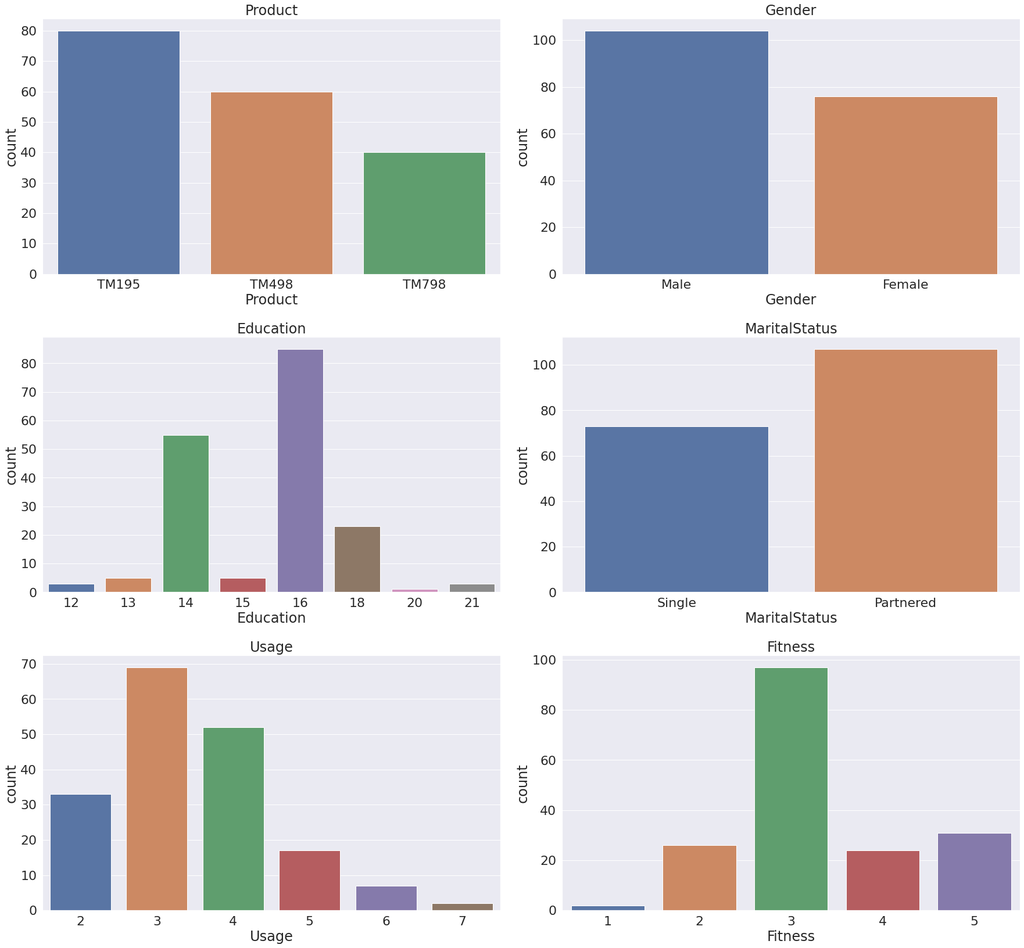

```python
#Explore the distribution of discrete numerical variables and categorical variables.
othercols= ['Product','Gender','Education','MaritalStatus','Usage','Fitness']
plt.figure(figsize=(25,30))
sns.set(font_scale=2)
for i, name in enumerate(othercols):
  plt.subplot(4,2,i+1)
  sns.countplot(data=df,x=name)
  plt.tight_layout()
  plt.title(name)
```

```python
#look at percentile distribution of variables
for i in othercols:
  print(df[i].value_counts(normalize=True))
```

```
TM195    0.444444
TM498    0.333333
TM798    0.222222
Name: Product, dtype: float64
Male      0.577778
Female    0.422222
Name: Gender, dtype: float64
16    0.472222
14    0.305556
18    0.127778
15    0.027778
13    0.027778
12    0.016667
21    0.016667
20    0.005556
Name: Education, dtype: float64
Partnered    0.594444
Single       0.405556
Name: MaritalStatus, dtype: float64
3    0.383333
4    0.288889
2    0.183333
5    0.094444
6    0.038889
7    0.011111
Name: Usage, dtype: float64
3    0.538889
5    0.172222
2    0.144444
4    0.133333
1    0.011111
Name: Fitness, dtype: float64
```

- There are 3 treadmill products with TM195 being the most popular.
- Most customers (58%) are male.
- Most customers (47%) have 16 years of education, which can be assumed to mean they finished a 4-year college. The next highest is 14 years, which could mean they finished some community college degree or are in the middle of a 4-year degree. Very few customers have just finished high school or are pursuing doctorate/professional degrees.
- Most customers have a partner (59%).
- Using the treadmill on the lower end 2-4 times per week (85%) is more common than the higher end (5+ times/week)
- Most customers would rate themselves as average fitness level (54%).

### Part 3: Multivariate Analysis

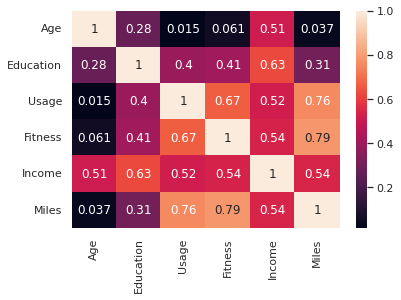

```python
#Find correlation between varialbes
sns.set(font_scale=1)
sns.heatmap(df.corr(),annot=True,cmap='rocket');
```

- As expected, the number of miles a customer expects to run is highly corrleated with the fitness level of the customer and number of times a customer uses the treadmill.
- The more education a customer has, the more income the customer makes.
- The older the customer is, the more income the customer makes.
- There is a positive correlation to a customer's income and how active (Fitness level, Usage, Miles) they are.
- All other variables show a correlation of less than 0.5.
- None of the variables have a negative correlation with each other.

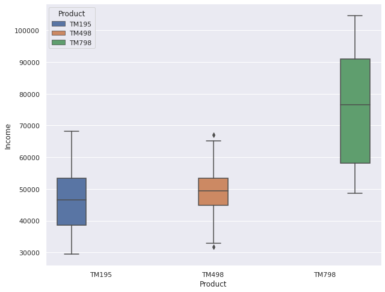

```python
#check income by product type
plt.figure(figsize=(10,8))
sns.boxplot(data=df,x='Product',y='Income',hue='Product');
```

- Customers who buy the TM798 treadmill make higher incomes than those that buy the TM195 or TM498.
- The TM195 and TM498 income distributions are similar, with the TM498 having a slightly higher median income.

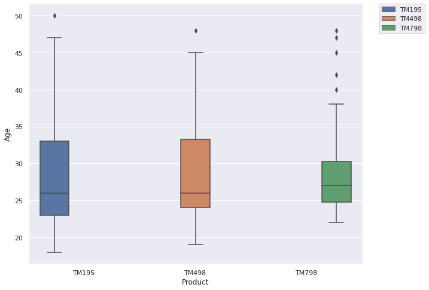

```python
#We know income is positively correlated with Age and since TM795 customers have high incomes, let's see how Age varies with Product.
plt.figure(figsize=(10,8))
sns.boxplot(data=df,x='Product',y='Age',hue='Product');
plt.legend(bbox_to_anchor=(1.05, 1), loc='upper left', borderaxespad=0)
```

- The median age across the 3 products is similar, with TM798 having a slightly higher median age.
- The minimum age of the customers who bought the TM798 is higher than those who bought the other products.

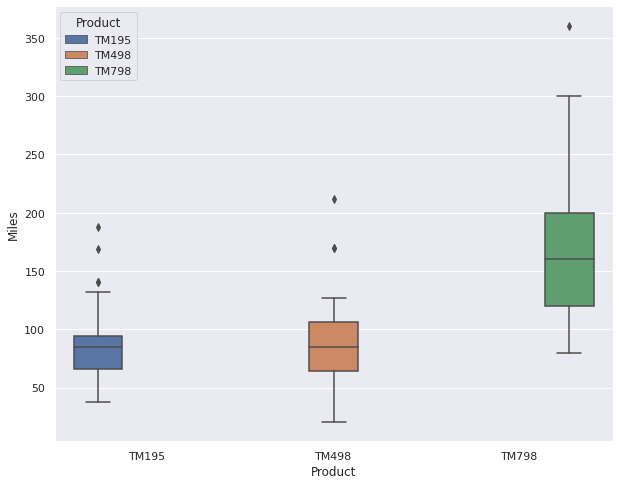

```python
#explore Miles vs. Product Type
plt.figure(figsize=(10,8))
sns.boxplot(data=df,x='Product',y='Miles',hue='Product');
```

- The number of miles that a customer expects to run who bought the TM798 is much higher than the those who bought the other two products.

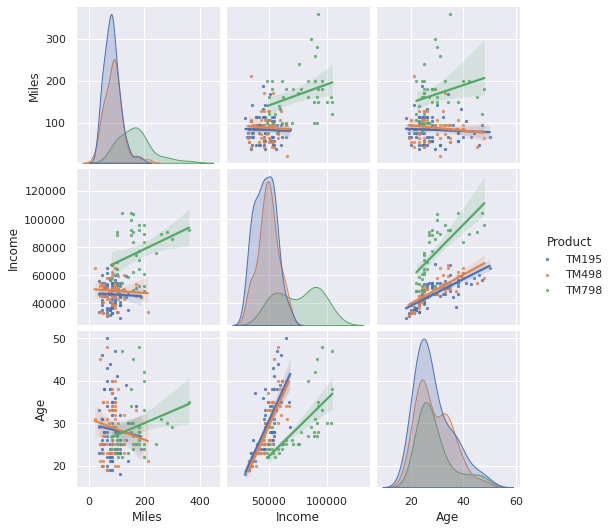

```python
contcols=['Miles','Income','Age','Product']
plt.figure(figsize=(20,15));
sns.pairplot(data=df[contcols],hue='Product',kind='reg',plot_kws=dict(scatter_kws=dict(s=5)));
```

- It is evident from the above graphs, that there is a lot of overlap in age across the different products, but there is a clear distinction when it comes to Miles and Income from the TM798 customers to the customers of the other two products.
- Customers of TM798 show positive correlation for the relationships between age, income, and miles.
- The customers of TM195 and TM498 actually appear to have a negative correlation between age vs. miles and income vs. miles.
- The regression lines of customers TM195 and TM498 have a lot of overlap, indicating similarities.

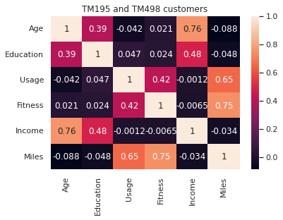

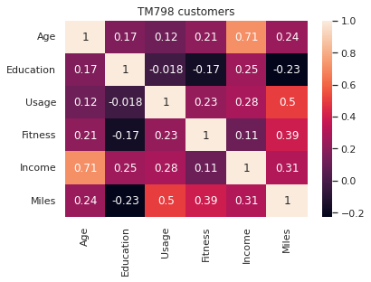

```python
#confirm the negative correlations seen above
sns.heatmap(df[(df['Product']=='TM195') | (df['Product']=='TM498')].corr(),annot=True,cmap='rocket');
plt.title("TM195 and TM498 customers")
plt.show()
sns.heatmap(df[(df['Product']=='TM798')].corr(),annot=True,cmap='rocket');
plt.title("TM798 customers");
```

- The TM195 and TM498 customers do show little to no correlation with age vs. miles and income vs. miles, fitness, and usage compared to TM798 customers.

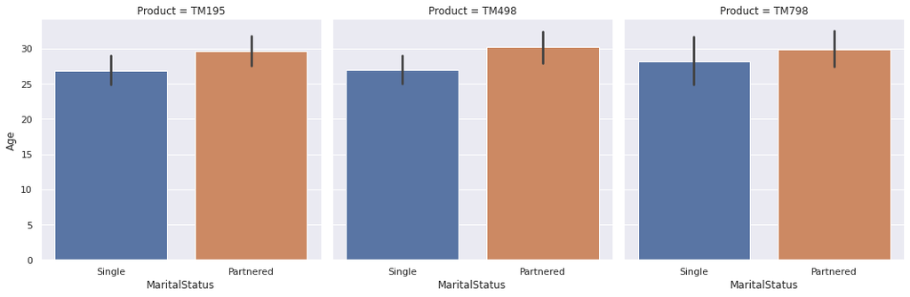

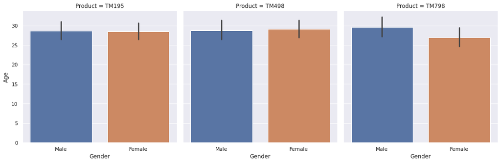

```python
#since Age had a similar distribution across the 3 products, let's see how it varies with Marital Status and Gender
sns.set(font_scale=1)
sns.catplot(data=df, x='MaritalStatus',y='Age', col='Product',kind='bar');
plt.show()
sns.catplot(data=df, x='Gender',y='Age', col='Product',kind='bar');
plt.show()
```

Ranges for males and females are similar for TM195 and TM498. The biggest difference in range is seen for the customers of TM798, where male customers are older than female customers.

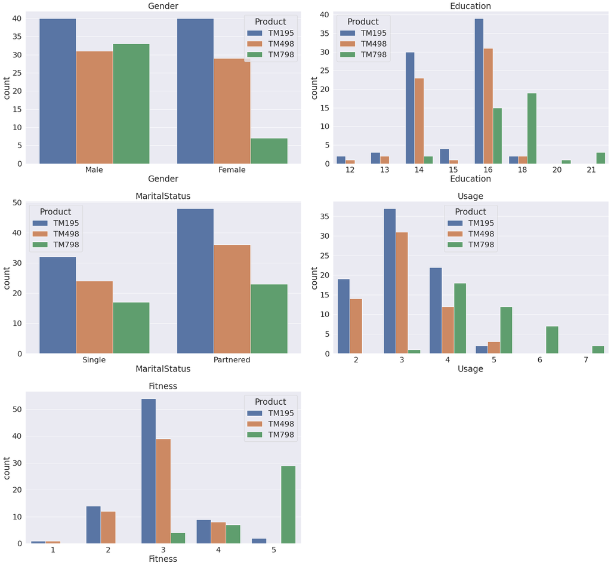

```python
#Find a relationship between discrete numerical variables and categorical variables
othercols= ['Gender','Education','MaritalStatus','Usage','Fitness']
plt.figure(figsize=(25,30))
sns.set(font_scale=2)
for i, name in enumerate(othercols):
  plt.subplot(4,2,i+1)
  sns.countplot(data=df,x=name,hue='Product')
  plt.tight_layout()
  plt.title(name)
```

1. TM195:
- Equal representation among males and females.
- Most customers have 16 years of education, and a max of 18 years.
- More customers have partners than are single.
- Customers use the treadmill 5 times or less/week.
- Most customers have a fitness level of 3.
1. TM498:
- Almost equal representation among males and females.
- Most customers have 16 years of education, and a max of 18 years.
- More customers have partners than are single.
- Customers use the treadmill 5 times or less/week.
- Most customers have a fitness level of 3.
- **Overall, a similar distribution to the TM195 across categories but the TM195 is more popular.**
1. TM798:
- More male than female customers.
- Most customers have a high number of years of education, from 14-21.
- More customers have partners than are single.
- Customers use than treadmill more often, 4 times per week.
- Most customers have higher fitness levels, from 3-5.

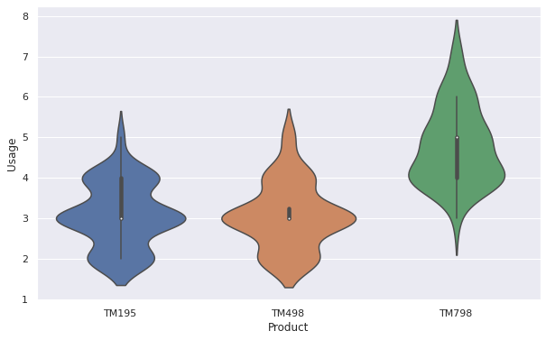

```python
plt.figure(figsize=(10,6))
sns.set(font_scale=1)
sns.violinplot(data=df,y='Usage',x='Product');
```

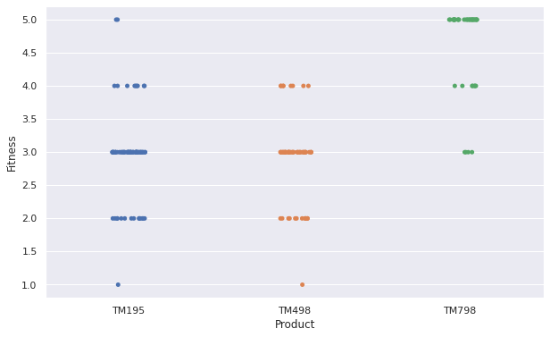

```python
plt.figure(figsize=(10,6))
sns.stripplot(data=df,y='Fitness',x='Product',jitter=True);
```

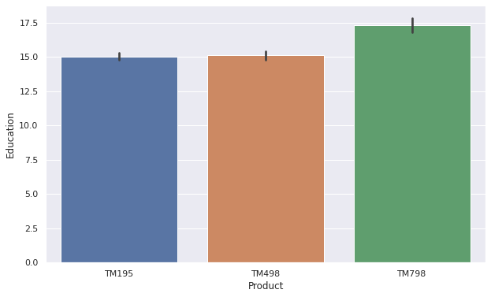

```python
plt.figure(figsize=(10,6))
sns.barplot(data=df,y='Education',x='Product');
```

- The above 3 plots confirm the relationships shown in the countplots. TM798 customers use the treadmill more often, are at a higher fitness level, and have more years of education over the average customer of TM195 or TM498.

```python
#look at the characteristics of the top customers for each product
cols = ['Age','Miles','Income']
for i in cols:
  t=i+'_bin'
  df[t]=pd.cut(df[i], bins=[df[i].min()-1,df[i].quantile(.25),df[i].quantile(.50),df[i].quantile(.75),df[i].max()],labels=[1,2,3,4], right=True)
df['Combined']=df[['Gender', 'Education', 'MaritalStatus', 'Usage',
                   'Fitness', 'Miles_bin','Income_bin','Age_bin']].apply(lambda row: '|'.join(row.values.astype(str)), axis=1)
for i in ['TM195','TM498','TM798']:
  print(i)
  print('Gender', 'Education', 'MaritalStatus', 'Usage','Fitness', 'Miles_bin','Income_bin','Age_bin',sep='|')
  print(df[df['Product']==i]['Combined'].value_counts(normalize=True).head(5))
  print('\n')
```

```
TM195
Gender|Education|MaritalStatus|Usage|Fitness|Miles_bin|Income_bin|Age_bin
Female|14|Partnered|2|3|1|2|3    0.0250
Female|16|Single|4|3|2|1|1       0.0250
Male|14|Single|3|4|3|1|1         0.0125
Male|14|Partnered|4|4|4|2|3      0.0125
Female|16|Single|2|2|1|3|3       0.0125
Name: Combined, dtype: float64


TM498
Gender|Education|MaritalStatus|Usage|Fitness|Miles_bin|Income_bin|Age_bin
Male|16|Partnered|3|3|3|3|3      0.050000
Male|16|Partnered|3|3|3|4|4      0.033333
Female|16|Single|3|3|3|2|1       0.033333
Male|14|Single|3|3|1|1|1         0.016667
Female|16|Partnered|4|3|3|4|4    0.016667
Name: Combined, dtype: float64


TM798
Gender|Education|MaritalStatus|Usage|Fitness|Miles_bin|Income_bin|Age_bin
Male|18|Partnered|4|5|4|4|4      0.050
Male|16|Single|5|5|4|4|4         0.050
Male|18|Partnered|5|4|4|4|3      0.025
Male|21|Partnered|4|4|3|4|3      0.025
Female|18|Partnered|6|5|4|4|3    0.025
Name: Combined, dtype: float64
```

- When looking at the characteristics of the customers who have the largest share, we can see the same trend in customers of TM798 in having higher incomes, being more educated, and being more fit. They also cover more of the older age ranges.
- We also notice more differences between TM195 and TM498. The top customers of TM195 make less income than the TM498 top customer. They are also female instead of male as shown in TM498.

#### Part 4: Outlier Detection and Treatment

The columns of Product, Gender, Marital Status, Usage, Education, and Fitness take on a predictable range of values as seen earlier. Age and Income boxplots showed outliers, but the range takes on acceptables values.

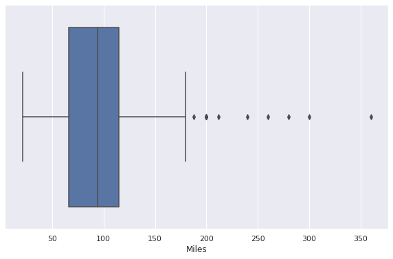

```python
#let's look at the Miles column more closely
plt.figure(figsize=(10,6))
sns.boxplot(data=df,x='Miles');
```

The max number of miles a customer expects to run is 360. This point could be an outlier since it is far from the next highest of 300. To tell if it is a true outlier, the timeframe (week, month, year, etc) would need to be confirmed with the business.

### Part 5: Conclusions and Recommendations

Conclusions:

A dataset of 180 observations containing customer characteristcs was analyzed. The data covered 3 different treadmill products. The main purpose was to see how customer characteristics varied across the 3 different treadmill products and what insights can help the business best target new customers.

The following conclusions were made:

1. Most customers are male, have 16 years of eduction, are partnered, use the treadmill 4 times or less per week, and are at an average fitness level. Customers have a median age of 26 and median income of $51k.
2. As expected, the number of miles a customer expects to run is highly corrleated with the fitness level of the customer and number of times a customer uses the treadmill.
3. The more education a customer has, the more income the customer makes.
4. The older the customer is, the more income the customer makes.
5. Age distributions across the 3 products are similar.
6. The TM195 treadmill is the most popular.
7. The TM195 and TM498 customers had very similar characteristics.
8. Customers of TM798 have a positive correlation between age or income vs. activity level (miles, usage, fitness) vs. a little to no correlation for the customers of TM195 and TM498.
9. Most customers of TM195 and TM498 have 16 years of education, use the treadmill 3 times/week, and have a fitness level of 3.
10. Most TM798 customers have 18 years of education, use the treadmill 4 times/week, and have a fitness level of 5.
11. TM798 male customers are mostly older than female customers.

Recommendations to Business:

1. The TM195/TM498 and TM798 products help capture two distinct types of customer groups.
2. The business should market the TM798 product to more educated, wealthy, and fit individuals: customers with high education levels, incomes, number of miles expected to run each week, usage, and fitness levels.
3. Since the TM195 and TM498 customer characteristics are very similar, it may help to further analyze the cannabilization between the two products and how we can differentiate them from a marketing standpoint.
4. The business should market the TM195 product to lower-income female customers when deciding whether to market the TM195 or TM498 product, as those customers make up the top customer characteristics of the TM195 product.
5. The business should target partnered customers over single customers as partnered customers make up the bigger share across all 3 products.

Further Analysis:

1. Confirm the timeframe for the miles variable to help detect any outliers and re-visualize the relationships after outlier treatment. It may also be beneficial to look at the average number of miles a customer usually runs instead of the expected number.
2. Get the prices of the treadmill products and see how price may be influencing some of the relationships found among customers of different products.
3. Understand the functional differences between the TM195 and TM498 products. If they are very similar, it may help explain the customer similarities between the two products.